# Case Study: Gene Set Enrichment Analysis (Human Data Set)

Alejandro Reyes and Keegan Korthauer

October 30, 2018

# 1 Summary

The objective of this document is to compare different methods for multiple testing correction in the context of Gene Set Enrichment Analysis (GSEA). We use RNA-seq data consisting of cortex and cerebellum samples of a subset of the GTEx individuals. Shortly, samples were downloaded using the *Short Read Archive Toolkit* and mapped to the human reference genome version GRCh38 using *STAR v2.4.2a*. *htseq-count* was used to tabulate the number of uniquely mapping reads for each gene. We used the `DESeq2` package to format the data into a `DESeqDataSet` object.

Here we use the `goseq` Bioconductor package to implement the gene set analysis. This is an Over-Representation Analysis which does requires setting an arbitrary threshold for Differential Expression. The test concerns whether any of the GO sets are enriched for DE genes.

# 2 Workspace Setup

```r
library(dplyr)
```

```r
library(ggplot2)
library(scales)
library(DESeq2)
library(EnsDb.Hsapiens.v86)
library(biomaRt)
library(goseq)
## load helper functions
for (f in list.files("../R", "\\.(r|R)$", full.names = TRUE)) {
    source(f)
}

## project data/results folders
datdir <- "data"
resdir <- "results"
sbdir <- "../../results/GSEA"
dir.create(datdir, showWarnings = FALSE)
dir.create(resdir, showWarnings = FALSE)
dir.create(sbdir, showWarnings = FALSE)

## intermediary files we create below
count_file <- file.path(datdir, "human-counts.rds")
deseq_file <- file.path(datdir, "human-deseq.rds")
goset_file <- file.path(datdir, "human-gosets.rds")
result_file <- file.path(resdir, "human-results-goseq.rds")
```

# 3 Data Preparation

We download the *DESeqDataSet* from zenodo, if not present locally, and modify the design to test for differences in gene expression between cerebellums and cortex.

```r
if (!file.exists(count_file)) {
    download.file("https://zenodo.org/record/1475409/files/gsea-human-counts.rds?download=1",
                  destfile = count_file)
}
dsdObject <- readRDS(count_file)
design( dsdObject ) <- ~ tissue
```

To keep running times short, we only perform differential tesing on protein coding genes, as specified in Ensembl release 86.

```r
gnType <- genes(EnsDb.Hsapiens.v86, column = "gene_biotype")
protGenes <- gnType$gene_id[gnType$gene_biotype == "protein_coding"]
dsdObject <- dsdObject[rownames(dsdObject) %in% protGenes, ]
```

# 4 Data Analysis

## 4.1 Enrichment Analysis

Next, we run DESeq2 to retrieve a list of differentially expressed genes at a FDR of 10%.

```r
if (!file.exists(deseq_file)) {
    dsdObject <- DESeq(dsdObject)
    res <- results(dsdObject, independentFiltering = FALSE)
    saveRDS(res, file = deseq_file)
} else {
    res <- readRDS(deseq_file)
}

genes <- as.numeric(res$padj < 0.1)
names(genes) <- rownames(res)
sum(genes, na.rm=TRUE)
```

```
## [1] 9853
```

Next we’ll use the biomaRt package to download and associate GO annotations for each gene.

```r
if (!file.exists(goset_file)) {
    mart <- useMart("ensembl", "hsapiens_gene_ensembl")
    goSets <- getBM(c("ensembl_gene_id", "go_id"), mart = mart,
                    filters = "ensembl_gene_id", values = rownames(res))
    goSets <- goSets[!nchar( goSets$go_id ) == 0, ]
    goSets <- with(goSets, split(go_id, ensembl_gene_id))
    saveRDS(goSets, file = goset_file)
} else {
    goSets <- readRDS(goset_file)
}
```

```r
if (!file.exists(result_file)) {
    ## get median transcript length for bias adjustment
    txByGene <- transcriptsBy(EnsDb.Hsapiens.v86, "gene")
    geneLength <- sapply(width(txByGene), median)
    geneLength <- geneLength[names(genes)]
    genes[is.na(genes)] <- 0

    ## perform gsea
    pwf <- nullp(genes, bias.data = geneLength)
    goRes <- goseq(pwf, gene2cat = goSets)

    saveRDS(goRes, file = result_file)
} else {
    goRes <- readRDS(result_file)
}

## Add random (uninformative) covariate
set.seed(66778)
goRes$rand_covar <- rnorm(nrow(goRes))
```

We filter out really small gene sets and those gene sets which have no DE genes in them (many of these are set to 1).

```r
goRes <- goRes %>%
  dplyr::filter(numDEInCat > 0, numInCat > 5 )
```

## 4.2 Covariate Diagnostics

Here, we want to check whether the size of the gene set is actually informative and independent under the null.

### 4.2.1 Gene Set Size

We will explore whether the size of the gene set can be used as a covariate for modern multiple-testing correction methods in the context of GSEA. In the plot below, the log10 of the p-values is plotted as a function of the size of the gene set. There is a pattern in which gene sets with a higher number of genes tend to have smaller p-values, which is indicative that gene set size is an informative covariate.

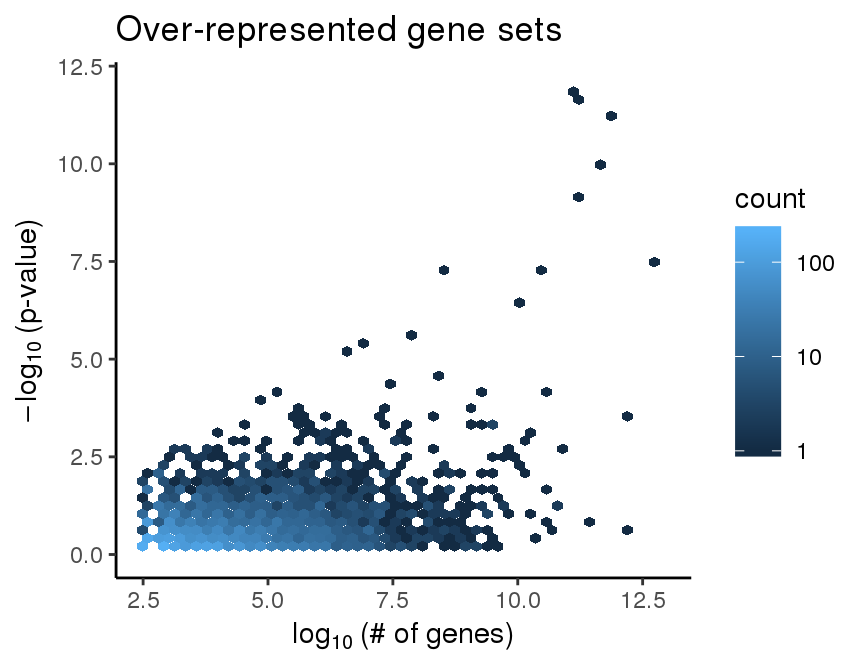

```r
rank_scatter(dat = goRes, pval = "over_represented_pvalue",
              covariate = "numInCat", bins = 50, funx = log2,
              funfill = log10_trans()) +
    ylim(0, 12) +
    ggtitle("Over-represented gene sets") +
    xlab(expression(log[10]~"(# of genes)")) +
    ylab(expression(-log[10]~"(p-value)") )
```

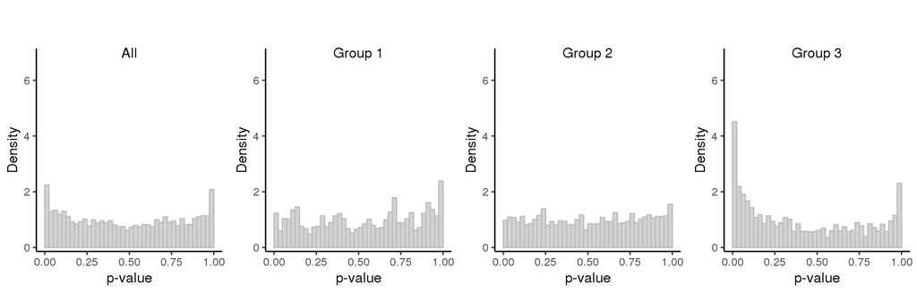

```r
strat_hist(goRes, pval="over_represented_pvalue", covariate="numInCat", maxy=7)
```

This suggests that the covariate is *not* independent under the null hypothesis, so the assumptions of many of the methods (which use an independent covariate) are not satisfied. Therefore we will not proceed with the benchmarking using these results.